# Intro to the survey and suRvey303 package

Robin Mejia & Francesca Matano

# Preliminaries

The purpose of this document is to give you a brief introduction and an overview of R’s survey package. The survey package is available on CRAN. We also built an R package named suRvey303 which combines the survey package with the data and the scripts that you will need for the homework. suRvey303 is specific for this class and you are going to be able to download it only when taking this class, from the ISLE platform.

All the files you need to run these examples are already included in the package, so you don’t need to worry about where to download it from.

## Installing the package

From the R console, call `install.packages('survey')` to install the package. Then load it by calling

```r
devtools::load_all()
```

```
## Loading suRvey303
```

```r
devtools::load_data()
library(magrittr)
library(ggplot2)
library(survey)
```

## Component description

The dataset you are going to be using is the combination of multiple dataset available here `https://wwwn.cdc.gov/nchs/nhanes/ContinuousNhanes/Default.aspx?BeginYear=2015`

# Importing the data

The data are already imported and saved in binary format, you only need to load the binary file. The first dataset that we will analyze here is named mydata, so go ahead and load the `mydata` file by using the function data

```r
data("mydata")
```

Let’s start looking at what each column represents

```r
colnames(mydata)
```

```
##  [1] "dmdborn4" "ridageyr" "riagendr" "ridreth3" "wtint2yr" "wtmec2yr"
##  [7] "sdmvpsu"  "sdmvstra" "bpxpls"   "bpxsy1"   "bpxdi1"   "bmxwt"
## [13] "bmxht"    "whd010"   "whd020"
```

```r
dim(mydata)
```

```
## [1] 6063   15
```

We left the original variables name so you can refer to the documentation. But from now on we will be using more intuitive labels

```r
names(mydata) <- c("country_birth", "age", "gender", "race"," wtint2yr", "wtmec2yr",
                  "sdmvpsu", "sdmvstra" ,"hr_pulse", "syst_pressure", "diast_pressure",  "weight", "height", "self_reported_height","self_reported_weight")
```

Let’s start by looking at the first few rows, checking the size of the reduced dataset, format of the columns, etc

```r
head(mydata)
```

```
##   country_birth age gender race  wtint2yr  wtmec2yr sdmvpsu sdmvstra
## 1             1  62      1    3 134671.37 135629.51       1      125
## 2             2  53      1    3  24328.56  25282.43       1      125
## 3             1  78      1    3  12400.01  12575.84       1      131
## 4             1  56      2    3 102718.00 102078.63       1      131
## 5             1  42      2    4  17627.67  18234.74       2      126
## 6             2  72      2    1  11252.31  10878.68       1      128
##   hr_pulse syst_pressure diast_pressure weight height self_reported_height
## 1       76           128             70   94.8  184.5                   74
## 2       72           146             88   90.4  171.4                   68
## 3       56           138             46   83.4  170.1                   69
## 4       78           132             72  109.8  160.9                   64
## 5       76           100             70   55.2  164.9                   64
## 6       64           116             58   64.4  150.0                   63
##   self_reported_weight
## 1                  212
## 2                  193
## 3                  182
## 4                  220
## 5                  125
## 6                  150
```

```r
dim(mydata)
```

```
## [1] 6063   15
```

```r
str(mydata)
```

```
## 'data.frame':    6063 obs. of  15 variables:
##  $ country_birth       : 'labelled' int  1 2 1 1 1 2 1 2 1 1 ...
##   ..- attr(*, "label")= chr "Country of birth"
##  $ age                 : 'labelled' int  62 53 78 56 42 72 22 32 18 56 ...
##   ..- attr(*, "label")= chr "Age in years at screening"
##  $ gender              : 'labelled' int  1 1 1 2 2 2 1 2 1 1 ...
##   ..- attr(*, "label")= chr "Gender"
##  $ race                : 'labelled' int  3 3 3 3 4 1 4 1 6 4 ...
##   ..- attr(*, "label")= chr "Race/Hispanic origin w/ NH Asian"
##  $  wtint2yr           : 'labelled' num  134671 24329 12400 102718 17628 ...
##   ..- attr(*, "label")= chr "Full sample 2 year interview weight"
##  $ wtmec2yr            : 'labelled' num  135630 25282 12576 102079 18235 ...
##   ..- attr(*, "label")= chr "Full sample 2 year MEC exam weight"
##  $ sdmvpsu             : 'labelled' int  1 1 1 1 2 1 2 1 2 2 ...
##   ..- attr(*, "label")= chr "Masked variance pseudo-PSU"
##  $ sdmvstra            : 'labelled' int  125 125 131 131 126 128 128 125 122 126 ...
##   ..- attr(*, "label")= chr "Masked variance pseudo-stratum"
##  $ hr_pulse            : 'labelled' int  76 72 56 78 76 64 66 74 NA 70 ...
##   ..- attr(*, "label")= chr "60 sec. pulse (30 sec. pulse * 2)"
##  $ syst_pressure       : 'labelled' int  128 146 138 132 100 116 110 120 NA 178 ...
##   ..- attr(*, "label")= chr "Systolic: Blood pres (1st rdg) mm Hg"
##  $ diast_pressure      : 'labelled' int  70 88 46 72 70 58 70 70 NA 116 ...
##   ..- attr(*, "label")= chr "Diastolic: Blood pres (1st rdg) mm Hg"
##  $ weight              : 'labelled' num  94.8 90.4 83.4 109.8 55.2 ...
##   ..- attr(*, "label")= chr "Weight (kg)"
##  $ height              : 'labelled' num  184 171 170 161 165 ...
##   ..- attr(*, "label")= chr "Standing Height (cm)"
##  $ self_reported_height: 'labelled' int  74 68 69 64 64 63 65 61 65 72 ...
##   ..- attr(*, "label")= chr "Current self-reported height (inches)"
##  $ self_reported_weight: 'labelled' int  212 193 182 220 125 150 170 128 150 247 ...
##   ..- attr(*, "label")= chr "Current self-reported weight (pounds)"
```

```r
summary(mydata)
```

```
##  country_birth         age            gender           race
##  Min.   : 1.000   Min.   :16.00   Min.   :1.000   Min.   :1.000
##  1st Qu.: 1.000   1st Qu.:29.00   1st Qu.:1.000   1st Qu.:2.000
##  Median : 1.000   Median :46.00   Median :2.000   Median :3.000
##  Mean   : 1.354   Mean   :46.34   Mean   :1.519   Mean   :3.235
##  3rd Qu.: 2.000   3rd Qu.:62.00   3rd Qu.:2.000   3rd Qu.:4.000
##  Max.   :99.000   Max.   :80.00   Max.   :2.000   Max.   :7.000
##
##     wtint2yr         wtmec2yr         sdmvpsu         sdmvstra
##  Min.   :  5331   Min.   :  5157   Min.   :1.000   Min.   :119.0
##  1st Qu.: 16744   1st Qu.: 17521   1st Qu.:1.000   1st Qu.:123.0
##  Median : 24358   Median : 25450   Median :1.000   Median :126.0
##  Mean   : 39577   Mean   : 41163   Mean   :1.486   Mean   :126.3
##  3rd Qu.: 42219   3rd Qu.: 44731   3rd Qu.:2.000   3rd Qu.:130.0
##  Max.   :233756   Max.   :242387   Max.   :2.000   Max.   :133.0
##
##     hr_pulse      syst_pressure   diast_pressure       weight
##  Min.   : 36.00   Min.   : 82.0   Min.   :  0.00   Min.   : 32.40
##  1st Qu.: 64.00   1st Qu.:112.0   1st Qu.: 62.00   1st Qu.: 65.20
##  Median : 72.00   Median :122.0   Median : 70.00   Median : 77.60
##  Mean   : 72.96   Mean   :124.4   Mean   : 69.06   Mean   : 80.78
##  3rd Qu.: 80.00   3rd Qu.:134.0   3rd Qu.: 76.00   3rd Qu.: 92.30
##  Max.   :140.00   Max.   :236.0   Max.   :120.00   Max.   :198.90
##  NA's   :163      NA's   :356     NA's   :356      NA's   :73
##      height      self_reported_height self_reported_weight
##  Min.   :129.7   Min.   :  47.0       Min.   :  75
##  1st Qu.:158.7   1st Qu.:  63.0       1st Qu.: 144
##  Median :166.1   Median :  66.0       Median : 170
##  Mean   :166.2   Mean   : 331.3       Mean   : 348
##  3rd Qu.:173.5   3rd Qu.:  69.0       3rd Qu.: 200
##  Max.   :202.7   Max.   :9999.0       Max.   :9999
##  NA's   :66      NA's   :2
```

Some of the variables are coded into 1,2,…, as explained in the data documentation

We will re-label some of these to make the dataset easier to read. Note that we only worry about the factors variables.

```r
mydata$country_birth <- factor(mydata$country_birth, levels = c(1, 2), labels = c("us50-dc", "other"))
mydata$gender <- factor(mydata$gender, levels = c(1, 2), labels = c("male", "female"))
mydata$race <- factor(mydata$race, levels = c(1:4, 6, 7), labels = c("mexican-american", "other-hispanic",
                                                               "non-hispanic_white", "non-hispanic_black",
                                                               "non-hipsanic_asian", "other_race"))
```

Moreover the self-reported weight and height are in different scale with respect to the measured weight and height. We will convert the weight from kg to pounds and height from cm to inches.

```r
mydata$weight <- mydata$weight*2.20
mydata$height <- mydata$height*0.39
```

Let’s take a look at the data now

```r
head(mydata)
```

```
##   country_birth age gender               race  wtint2yr  wtmec2yr sdmvpsu
## 1       us50-dc  62   male non-hispanic_white 134671.37 135629.51       1
## 2         other  53   male non-hispanic_white  24328.56  25282.43       1
## 3       us50-dc  78   male non-hispanic_white  12400.01  12575.84       1
## 4       us50-dc  56 female non-hispanic_white 102718.00 102078.63       1
## 5       us50-dc  42 female non-hispanic_black  17627.67  18234.74       2
## 6         other  72 female   mexican-american  11252.31  10878.68       1
##   sdmvstra hr_pulse syst_pressure diast_pressure weight height
## 1      125       76           128             70 208.56 71.955
## 2      125       72           146             88 198.88 66.846
## 3      131       56           138             46 183.48 66.339
## 4      131       78           132             72 241.56 62.751
## 5      126       76           100             70 121.44 64.311
## 6      128       64           116             58 141.68 58.500
##   self_reported_height self_reported_weight
## 1                   74                  212
## 2                   68                  193
## 3                   69                  182
## 4                   64                  220
## 5                   64                  125
## 6                   63                  150
```

# Getting familiar with the dataset

Before going through the survey.design object we will get familiar with the data. In order to do this we will visualize the distribution of the variables and the conditional distributions.

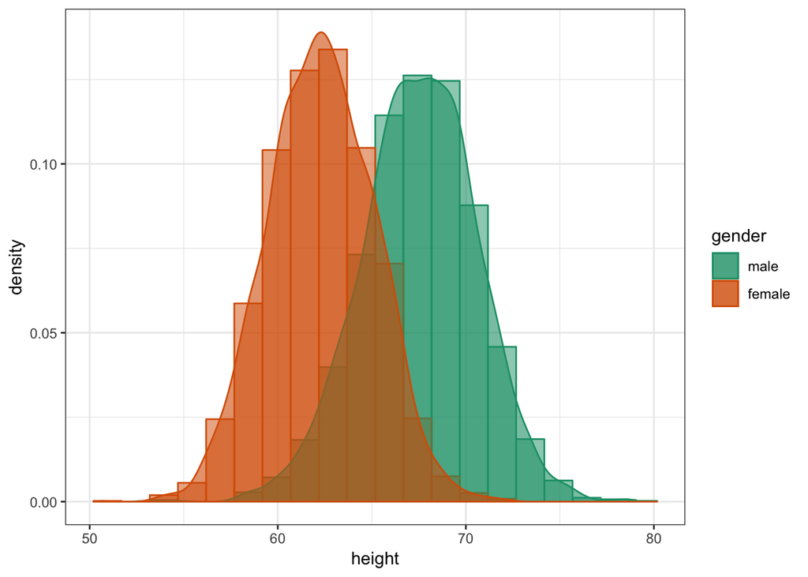

```r
ggplot(mydata, aes(x = height, color = gender, fill = gender)) +
  geom_histogram(aes(y=..density..), position="identity", bins = 20, alpha=0.5) +
  scale_color_brewer(palette = "Dark2")+
  scale_fill_brewer(palette = "Dark2") +
  geom_density(alpha = 0.6) +
  theme_bw()
```

## Interesting facts

It turns out there exist some interesting relationship between gender and misreported measures. Let’s take a look at them.

```r
new_data_f <- subset(mydata, gender == "female")[,c("weight", "self_reported_weight")] %>%
  reshape2::melt(measure.vars = c("weight", "self_reported_weight"), variable.name = "rec_type",
                 value.name = "measurement")
levels(new_data_f$rec_type) <- c("measured", "self-reported")

new_data_m  <- subset(mydata, gender == "male")[,c("weight", "self_reported_weight")] %>%
  reshape2::melt(measure.vars = c("weight", "self_reported_weight"), variable.name = "rec_type",
                 value.name = "measurement")
levels(new_data_m$rec_type) <- c("measured", "self-reported")

# exclude missing values coded with high numbers
new_data_f$measurement[new_data_f$measurement > 7000] <- NA
new_data_m$measurement[new_data_m$measurement > 7000] <- NA
```

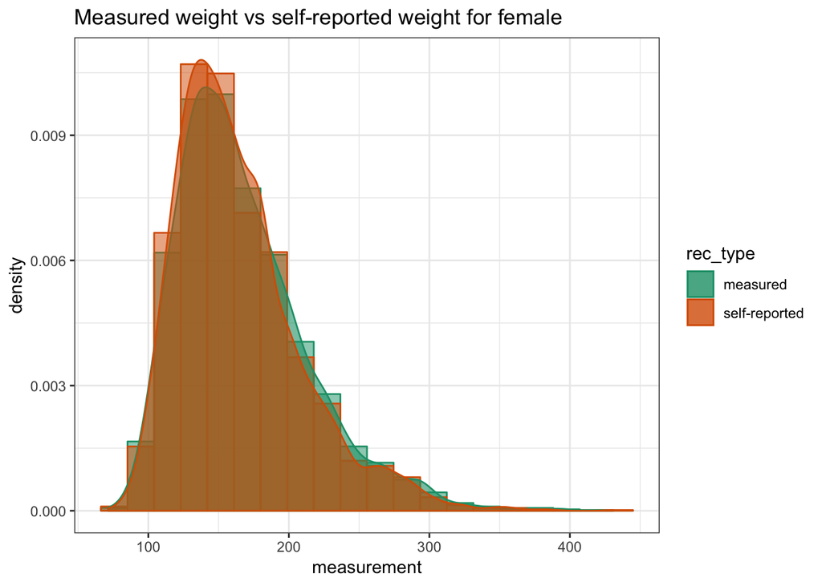

```r
ggplot(new_data_f, aes(x = measurement, color = rec_type, fill = rec_type)) +
  geom_histogram(aes(y=..density..), position="identity", bins = 20, alpha = 0.5) +
  scale_color_brewer(palette = "Dark2")+
  scale_fill_brewer(palette = "Dark2") +
  geom_density(alpha = 0.6) +
  ggtitle("Measured weight vs self-reported weight for female") +
  theme_bw()
```

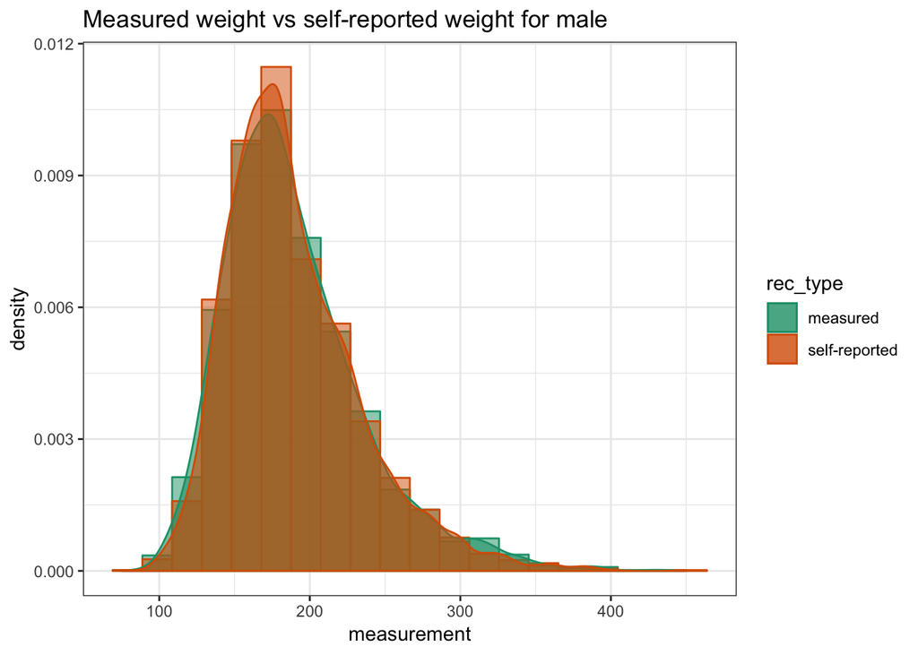

```r
ggplot(new_data_m, aes(x = measurement, color = rec_type, fill = rec_type)) +
  geom_histogram(aes(y=..density..), position="identity", bins = 20, alpha=0.5) +
  scale_color_brewer(palette = "Dark2")+
  scale_fill_brewer(palette = "Dark2") +
  geom_density(alpha = 0.6) +
  ggtitle("Measured weight vs self-reported weight for male") +
  theme_bw()
```

We can do the same for height and self-reported height. We first re-format the data

```r
new_data_f <- subset(mydata, gender == "female")[,c("height", "self_reported_height")] %>%
  reshape2::melt(measure.vars = c("height", "self_reported_height"), variable.name = "rec_type",
                 value.name = "measurement")
levels(new_data_f$rec_type) <- c("measured", "self-reported")

new_data_m  <- subset(mydata, gender == "male")[,c("height", "self_reported_height")] %>%
  reshape2::melt(measure.vars = c("height", "self_reported_height"), variable.name = "rec_type",
                 value.name = "measurement")
levels(new_data_m$rec_type) <- c("measured", "self-reported")

# exclude missing values coded with high numbers
new_data_f$measurement[new_data_f$measurement > 7000] <- NA
new_data_m$measurement[new_data_m$measurement > 7000] <- NA
```

We then exclude missing values and plot the results

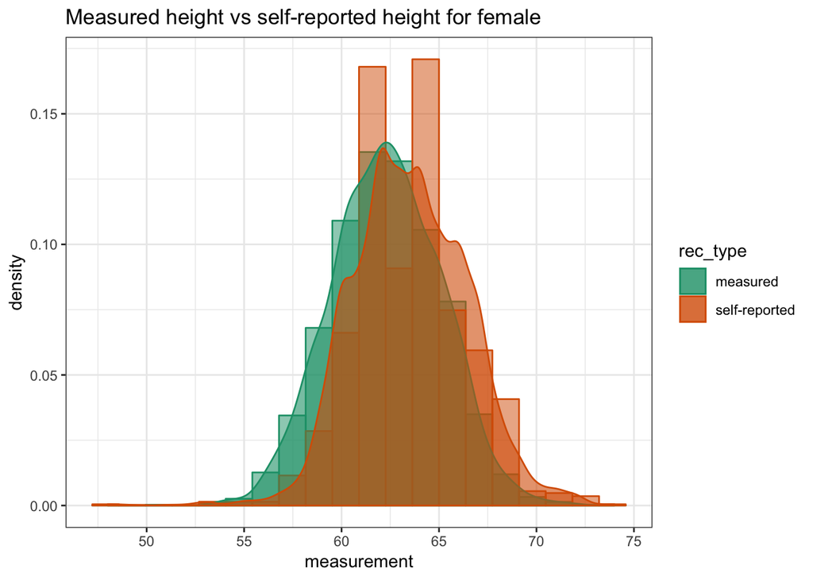

```r
ggplot(new_data_f, aes(x = measurement, color = rec_type, fill = rec_type)) +
  geom_histogram(aes(y=..density..), position="identity", bins = 20, alpha = 0.5) +
  scale_color_brewer(palette = "Dark2")+
  scale_fill_brewer(palette = "Dark2") +
  geom_density(alpha = 0.6) +
  ggtitle("Measured height vs self-reported height for female") +
  theme_bw()
```

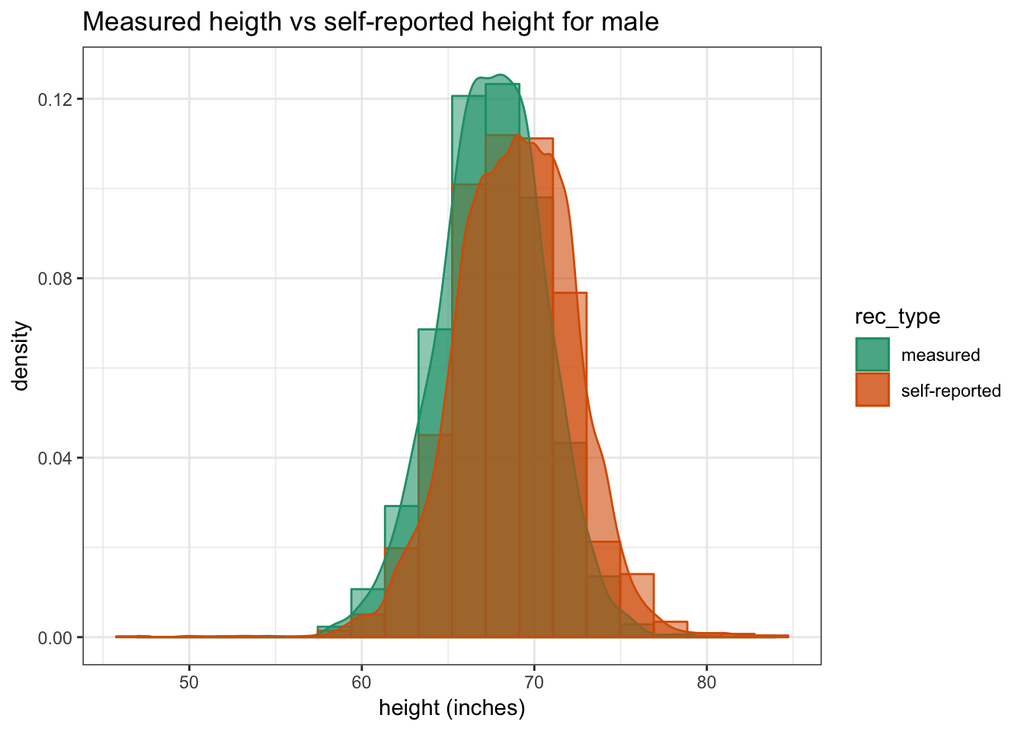

```r
ggplot(new_data_m, aes(x = measurement, color = rec_type, fill = rec_type)) +
  geom_histogram(aes(y=..density..), position="identity", bins = 20, alpha=0.5) +
  scale_color_brewer(palette = "Dark2")+
  scale_fill_brewer(palette = "Dark2") +
  geom_density(alpha = 0.6) +
  xlab("height (inches)") +
  ggtitle("Measured heigth vs self-reported height for male") +
  theme_bw()
```

We can also look at blood pressure by race

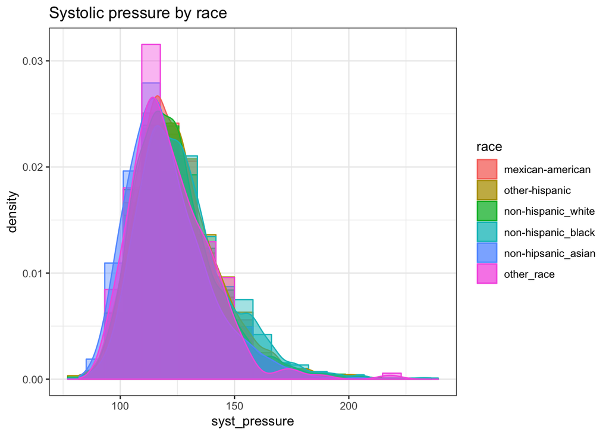

```r
ggplot(mydata, aes(x = syst_pressure, color = race, fill = race)) +
  geom_histogram(aes(y=..density..), position="identity", bins = 20, alpha=0.4) +
  geom_density(alpha = 0.6) +
  ggtitle("Systolic pressure by race") +
  theme_bw()
```

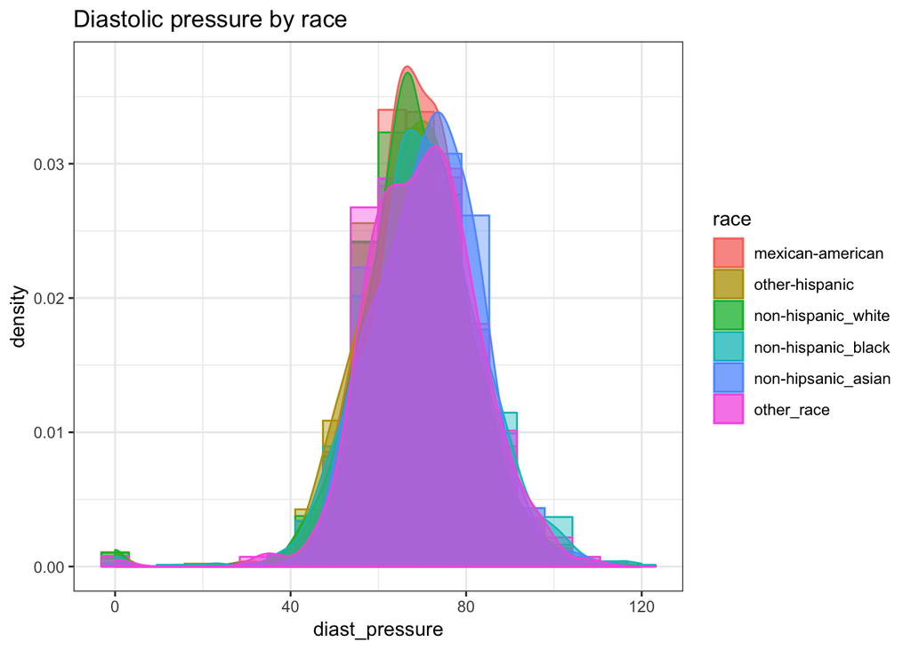

```r
ggplot(mydata, aes(x = diast_pressure, color = race, fill = race)) +
  geom_histogram(aes(y=..density..), position="identity", bins = 20, alpha=0.4) +
  geom_density(alpha = 0.6) +
  ggtitle("Diastolic pressure by race") +
  theme_bw()
```

### Creating the `survey.design` object

The survey package provides a `survey.design` object, which is a container for a dataset and the sampling design information, including sampling scheme, weights, population sizes (and more).

The `svydesign` function is used to create `survey.design` objects. It has a number of arguments, but the most important for you are:

- `ids`: Name of variable in the dataframe that contains cluster ids
- `strata`: Names of stratification variables, as a formula: `~var1 + var2 + var3`
- `fpc`: A vector the same length as the data, giving the stratum population size for each *observation*. The name is confusing, since you don’t actually supply the finite population correction factor.
- `data`: Dataframe containing the raw survey data

For this example we will use our data from the NHANES 2015-2016. From the Data collection procedure, `https://wwwn.cdc.gov/nchs/nhanes/ContinuousNhanes/Overview.aspx?BeginYear=2015` you can see that in 2015-2016, 15,327 persons were selected for NHANES from 30 different survey locations. Of those selected, 9,971 completed the interview and 9,544 were examined. In this case there were $N$ is the population of the US, $N=327600000$

```r
N = 327600000
n = nrow(mydata)
des = svydesign(ids = ~sdmvpsu,
                # strata = ~sdmvstra,
                fpc = rep(N, n),
                weights = ~wtmec2yr,
                data = mydata
                )
```

Let’s see what the results look like:

```r
summary(des)
```

```
## 1 - level Cluster Sampling design
## With (2) clusters.
## svydesign(ids = ~sdmvpsu, fpc = rep(N, n), weights = ~wtmec2yr,
##     data = mydata)
## Probabilities:
##      Min.   1st Qu.    Median      Mean   3rd Qu.      Max.
## 4.126e-06 2.236e-05 3.929e-05 4.403e-05 5.708e-05 1.939e-04
## Population size (PSUs): 327600000
## Data variables:
##  [1] "country_birth"        "age"                  "gender"
##  [4] "race"                 " wtint2yr"            "wtmec2yr"
##  [7] "sdmvpsu"              "sdmvstra"             "hr_pulse"
## [10] "syst_pressure"        "diast_pressure"       "weight"
## [13] "height"               "self_reported_height" "self_reported_weight"
```

### Estimates with the survey package

Once we’ve created the `survey.design` object `des` we can start computing things! the survey package provides a number of `svy*` functions that are similar to built in R functions, but account for survey design features.

To calculate a mean, with the correct SE (including the fpc):

```r
svymean(~age, design = des)
```

```
##       mean     SE
## age 46.091 0.3985
```

Like most of the functions in the survey package, `svymean` relies on R formulas to select variables. These are similar to the formulas you’re familiar with from `lm` for example, but are often one-sided (as above). This looks awkward but can actually be convenient, since you can do things like transform variables on the fly:

```r
svymean(~log10(age), design = des)
```

```
##              mean     SE
## log10(age) 1.6252 0.0042
```

Totals and proportions are computed similarly:

```r
svytotal(~gender, des)
```

```
##                  total      SE
## gendermale   120038626 1358972
## genderfemale 129531068 7552606
```

```r
svymean(~gender, des)
```

```
##                 mean     SE
## gendermale   0.48098 0.0117
## genderfemale 0.51902 0.0117
```

To calculate subgroup statistics with the correct SE’s, you can use `svyby`:

```r
svyby(~age, by=~gender, design=des, FUN = svymean)
```

```
##        gender      age        se
## male     male 45.46407 0.2208420
## female female 46.67241 0.5357616
```

These standard errors are corrected to account for the random denominators (subgroup sizes). If you’re only interested in particular subgroups, you can use the `subset` function too:

```r
svymean(~age,  design=subset(des, race == "other-hispanic"))
```

```
##       mean     SE
## age 41.009 0.7895
```

You can compute confidence intervals by hand, using the formulas based on the CLT, or using the `confint` function:

```r
confint(svymean(~age, des))
```

```
##        2.5 %  97.5 %
## age 45.31025 46.8722
```

#### Linear Regression

For fitting regression models, use `svyglm`. The interface is very similar to the core `lm` or `glm` functions:

```r
linear.reg = svyglm(diast_pressure ~ gender + age + race + height + weight, design = des)
summary(linear.reg)
```

```
##
## Call:
## svyglm(formula = diast_pressure ~ gender + age + race + height +
##     weight, design = des)
##
## Survey design:
## svydesign(ids = ~sdmvpsu, fpc = rep(N, n), weights = ~wtmec2yr,
##     data = mydata)
##
## Coefficients:
##                          Estimate Std. Error
## (Intercept)            43.5561060        Inf
## genderfemale            0.0128313        Inf
## age                     0.0320237        Inf
## raceother-hispanic      0.3205767        Inf
## racenon-hispanic_white -0.0003175        Inf
## racenon-hispanic_black  0.7955901        Inf
## racenon-hipsanic_asian  4.0466116        Inf
## raceother_race          0.0224062        Inf
## height                  0.2823615        Inf
## weight                  0.0319464        Inf
##
## (Dispersion parameter for gaussian family taken to be 147.3858)
##
## Number of Fisher Scoring iterations: 2
```

Standard diagnostics are available to you as well, for example:

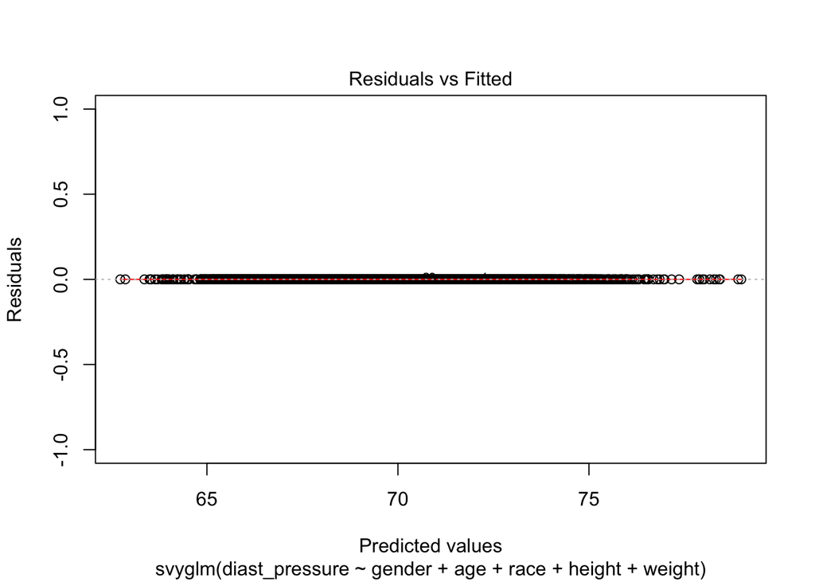

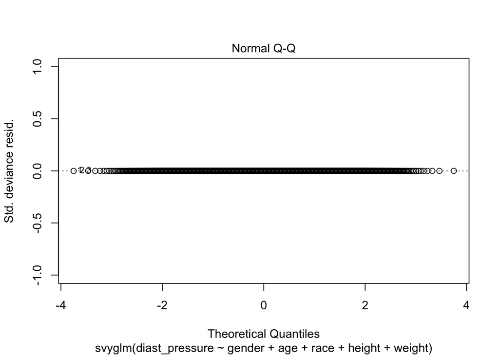

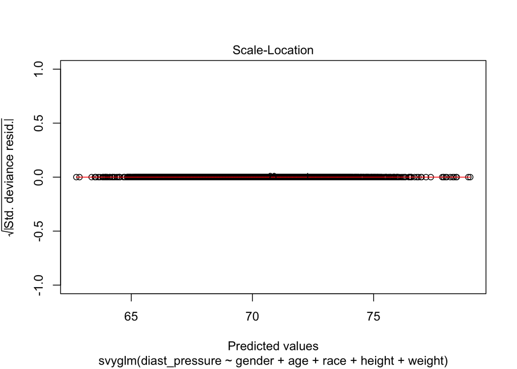

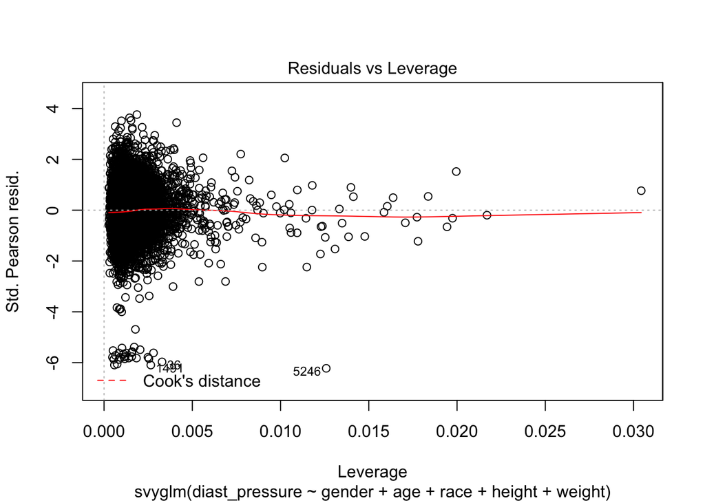

```r
plot(linear.reg)
```

#### Logistic Regression

For logistic regression we have to transform the response into a numeric variable taking values 0 or 1, and specify `family=quasibinomial()` (this is essentially the same as using `family=binomial` in `glm` but avoids pesky warnings):

```r
# Create the 2-level variable
dias_pressure_logistic <- rep(0, nrow(mydata))
dias_pressure_logistic[mydata$diast_pressure > 75] <- 1
mydata$dias_pressure_logistic <- dias_pressure_logistic

# re-estimate the design object
des = svydesign(ids = ~1,
                    strata = NULL,
                    fpc = rep(N, n),
                    data = mydata
                    )

logistic.reg = svyglm(dias_pressure_logistic ~ gender + age + race + height + weight, design = des, family=quasibinomial())
summary(logistic.reg)
```

```
##
## Call:
## svyglm(formula = dias_pressure_logistic ~ gender + age + race +
##     height + weight, design = des, family = quasibinomial())
##
## Survey design:
## svydesign(ids = ~1, strata = NULL, fpc = rep(N, n), data = mydata)
##
## Coefficients:
##                          Estimate Std. Error t value Pr(>|t|)
## (Intercept)            -3.9190959  0.7737863  -5.065 4.21e-07 ***
## genderfemale           -0.1997789  0.0823553  -2.426   0.0153 *
## age                     0.0095981  0.0014547   6.598 4.52e-11 ***
## raceother-hispanic      0.1288886  0.1082057   1.191   0.2336
## racenon-hispanic_white -0.0311886  0.0941866  -0.331   0.7406
## racenon-hispanic_black  0.2071699  0.0969842   2.136   0.0327 *
## racenon-hipsanic_asian  0.6462206  0.1096557   5.893 4.00e-09 ***
## raceother_race          0.2799963  0.1623417   1.725   0.0846 .
## height                  0.0241844  0.0118727   2.037   0.0417 *
## weight                  0.0053633  0.0006673   8.038 1.09e-15 ***
## ---
## Signif. codes:  0 '***' 0.001 '**' 0.01 '*' 0.05 '.' 0.1 ' ' 1
##
## (Dispersion parameter for quasibinomial family taken to be 0.994084)
##
## Number of Fisher Scoring iterations: 4
```